# From fictional trial records to survival analysis

Jack Lai

## What I wanted to check

I built this example to follow a trial record from collection to a result I could explain. Every subject and measurement is generated. The treatment difference is programmed into the generator, so none of these results support a medical claim.

This run starts with **120 fictional subjects**, releases **119** for analysis, and raises **5 open queries**. A query is a question a data manager would send back to the person checking the original record. The quality report beside the input files gives those questions and their source rows.

Records with errors are quarantined. A demographic or terminal-disposition error excludes that subject everywhere; a vital-sign, laboratory, event or dose error excludes that record. The survival calculation needs the demographic and disposition records. Open safety-record queries still need review before anyone could summarize safety or lock a real study database.

## Who is included

The table uses all eligible subjects in each assigned arm. Age is in years. The female, male and unknown-sex columns are counts with the arm’s `n` as their denominator. Quartiles describe the middle half of the ages.

| arm | n | age_median | age_q1 | age_q3 | female | male | unknown_sex | deaths | censored |
| --- | --- | --- | --- | --- | --- | --- | --- | --- | --- |
| PLACEBO | 59 | 51 | 35 | 63.5 | 33 | 26 | 0 | 43 | 16 |
| ACTIVE | 60 | 55 | 42 | 67.0 | 26 | 34 | 0 | 37 | 23 |

## Time to death

Time starts at randomization. A death is an event; a subject alive at their last recorded contact is right-censored, which means the later outcome is unknown. Elapsed time is the number of days between the two dates, rather than the SDTM convention that labels the starting day as day 1. The analysis rejects missing or duplicate dispositions, nonpositive follow-up and dates that disagree across the input tables.

A Kaplan-Meier curve estimates the fraction surviving over time while accounting for subjects whose follow-up ends early. Dotted lines show 95% confidence limits; crosses show censoring. The risk table counts subjects still under observation just before each listed day. Rows after an arm’s last observation are omitted.

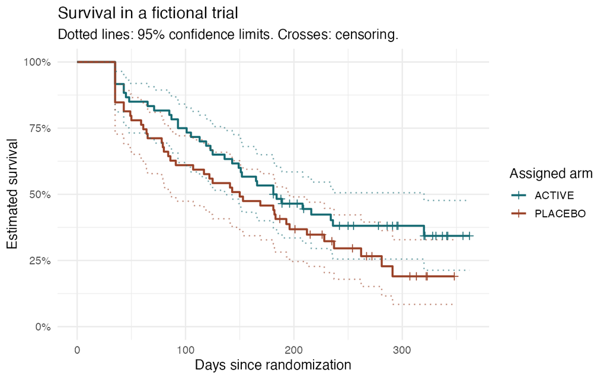

| arm | day | n_at_risk |
| --- | --- | --- |
| PLACEBO | 0 | 59 |
| PLACEBO | 90 | 37 |
| PLACEBO | 180 | 27 |
| PLACEBO | 270 | 8 |
| ACTIVE | 0 | 60 |
| ACTIVE | 90 | 47 |
| ACTIVE | 180 | 32 |
| ACTIVE | 270 | 15 |

## Adjusting for age and sex

The Cox model compares ACTIVE with PLACEBO while adjusting for age (per year) and recorded sex (M relative to F in this generated cohort). A hazard ratio below 1 corresponds to a lower estimated instantaneous death rate. The interval gives uncertainty in that estimate. This is an assigned-arm demonstration, not a per-protocol analysis or an ADaM submission dataset.

| term | hazard_ratio | lower_95 | upper_95 | p_value |
| --- | --- | --- | --- | --- |
| armACTIVE | 0.6667 | 0.4261 | 1.0432 | 0.0759 |
| age | 1.0162 | 1.0014 | 1.0312 | 0.0314 |
| sexM | 1.2156 | 0.7693 | 1.9207 | 0.4030 |

The model assumes that hazard ratios stay roughly constant over follow-up and that censoring is independent of the unobserved outcome conditional on the covariates. The scaled Schoenfeld-residual test below checks the proportional-hazards assumption; a small p-value is a warning to investigate. A large p-value does not prove the assumption. The small synthetic cohort and deliberately chosen outcome mechanism limit interpretation.

| term | chisq | df | p |
| --- | --- | --- | --- |
| arm | 0.0878 | 1 | 0.7670 |
| age | 8.6419 | 1 | 0.0033 |
| sex | 1.2667 | 1 | 0.2604 |
| GLOBAL | 11.9638 | 3 | 0.0075 |

This run flags a possible proportional-hazards violation. I would investigate time-varying effects before interpreting the adjusted hazard ratios as a stable treatment comparison.